# Behaviour of Customer of Ford GoBike System in 2018

## by Abdulrahman Alkhaldi

## Investigation Overview

In this investigation, I wanted to look at the behaviour of the customers of Ford GoBike System that could be used to minimizing the cost of operating the stations and the othr facilities. The main focus was on the gender and the time related columns (Month, Day and Hour).

## Dataset Overview

The document consists of information regarding approximately 1.86M bike rides made in a bike-sharing system (Ford GoBike) from fiscal year 2018. Including the trip start/end time, start/end station, duration in seconds as well as additional information such as user type, gender, and birth year.

## Bikes Monthly Usage

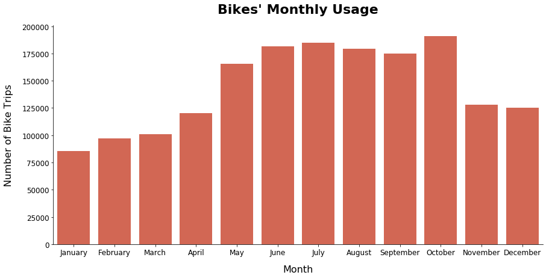

```python
months_ticks = ['January', 'February', 'March', 'April', 'May', 'June', 'July', 'August',
                'September', 'October', 'November', 'December'];

fig = sb.catplot( data = df_clean, x = 'start_month', kind = 'count', color = colors[0])
plt.xlabel('Month', labelpad = 14,fontsize = 16)
plt.ylabel('Number of Bike Trips', labelpad = 14,fontsize = 16)
plt.title('Bikes\' Monthly Usage', y = 1, fontsize = 22, fontweight='semibold', pad = 20);
fig.set_xticklabels(months_ticks)

plt.tick_params(axis='x', labelsize=12)
plt.tick_params(axis='y', labelsize=12)

plt.gcf().set_size_inches(14,6)
plt.figsize=(13,6)
```

## Usage Time for Each User Type

- **Subscribers:** Use bikes mainly on weekdays and at work timings. So, they clearly use it to commute to work.
  - Weekdays: Most rides are at (8 AM - 9 AM) and (5 PM - 6 PM), and its peak is at (Tuesdays, 8 AM).
  - Weekends: There is a significant drop in the demand of bikes compared to weekdays.
- **Customers:** Use bikes more often on weekends for touring and leisure.
  - Weekdays: Most rides are at (8 AM - 9 AM) and (5 PM - 6 PM), and its peak is at (Friday, 5 PM).
  - Weekends: Most rides are at (10 AM - 7 PM), and its peak is at (Saturday, 2 PM).

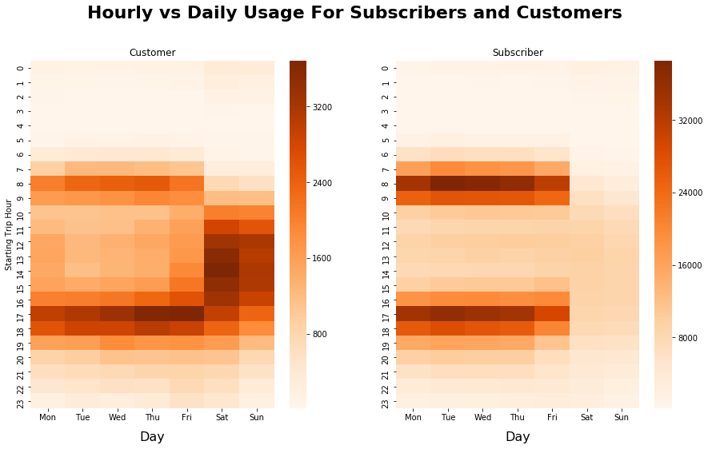

```python
df_clean['start_day'] = pd.Categorical(df_clean['start_day'], ordered=True,
                                                categories=['Mon','Tue','Wed','Thu','Fri','Sat', 'Sun'])
plt.figure(figsize=(15,8))
plt.suptitle('Hourly vs Daily Usage For Subscribers and Customers', fontsize = 22, fontweight='semibold', y = 1)

#Customers
plt.subplot(1, 2, 1)
df_customer = df_clean.query('user_type == "Customer"').groupby(["start_hour", "start_day"])["bike_id"].size().reset_index()
df_customer = df_customer.pivot("start_hour", "start_day", "bike_id")
sb.heatmap(df_customer, cmap = 'Oranges')
plt.title("Customer", y = 1.015)
plt.xlabel('Day', fontsize = 16, labelpad = 12)
plt.ylabel('Starting Trip Hour')

#Subscribers
plt.subplot(1, 2, 2)
df_subscriber = df_clean.query('user_type == "Subscriber"').groupby(["start_hour", "start_day"])["bike_id"].size().reset_index()
df_subscriber = df_subscriber.pivot("start_hour", "start_day", "bike_id")
sb.heatmap(df_subscriber, cmap="Oranges")
plt.title("Subscriber", y = 1.015)
plt.xlabel('Day', fontsize = 16, labelpad = 12)
plt.ylabel('');
```

## Bike Rides Per Gender

The plot shows an intersting fact that males rides are approximately 3 times more than females rides.

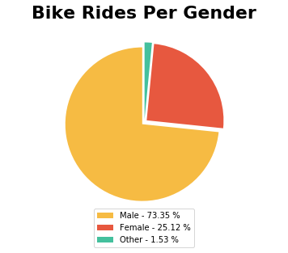

```python
x = np.char.array(['Male', 'Female', 'Other'])
y = np.array(list(df_clean[df_clean['member_gender'] != 'None']['member_gender'].value_counts())[0:3])

porcent = 100.*y/y.sum()
explode = (0.5, 0.5, 0.5)

patches, texts = plt.pie(y, startangle=90, radius = 13, explode = explode, colors = [colors[1], colors[0], colors[2]]);
labels = ['{0} - {1:1.2f} %'.format(i,j) for i,j in zip(x, porcent)]

plt.legend(patches, labels, loc='center right', bbox_to_anchor=(0.7, -0.1), fontsize = 10)
plt.axis('equal');
plt.title('Bike Rides Per Gender',   y = 1, fontsize = 22, fontweight='semibold', pad = 20);
```